# German Credit Scoring Data

Sankirna Joshi

06/04/2020

## German Credit Scoring Data

### Executive Summary

The German credit data set contains 1000 observations and 21 variables with “response” being the response variable. There are no empty observations. This data defines 20 variables that are used in credit scoring decisions for those who apply to a bank for a loan. The bank wants to minimize risk and maximize its profit by loaning to those who are good credit risks and not loaning to those who are bad risks, however there is a cost to each wrong decision. Cost is higher for a loan that defaults, than not loaning to someone who would pay back the loan

### Goal

Misclassification table calculation: For Credit Score data, you may use cut-off probability 1/6 (equivalent to 5:1 asymmetric cost). For Bankruptcy data, you may use cut-off probability 1/36 (equivalent to 35:1 asymmetric cost).

Random sample a training data set that contains 70% of original data points. Fit a generalized linear (logistic) regression, classification tree, generalized additive models, and neural network; Write a brief report up to eight pages including all labeled figures and tables. Compare different model performance based on fits of the training data (insample).

Test the out-of-sample performance. Using final model built from the 70% of original data, test with the remaining 30% testing data. Compare the out-of-sample model performance.

### Approach

We fit a generalized logistic regression model, classification tree, generalized additive model, and neural network and compare the perfomances and summarize the major findings below:

### Major Findings

- GAMS and Neural Networks work the best on the problem with the losest out-of-sample misclassification rate.
- The performance of a decision tree is worse compared to the above two models. We will nieed to employ techniques like random forests, bagging, boosting to imcrease the performance of classification trees.
- Logistic Regression is unable to find the pattern in the dataset well and we can include regularization to imporve its performance.

## Logistic Regression

```
## Start:  AIC=700.89
## response ~ chk_acct + duration + credit_his + purpose + amount +
##     saving_acct + present_emp + installment_rate + sex + other_debtor +
##     present_resid + property + age + other_install + housing +
##     n_credits + job + n_people + telephone + foreign
##
##                    Df Deviance    AIC
## - job               3   603.19 695.19
## - present_emp       4   608.56 698.56
## - property          3   606.73 698.73
## - present_resid     1   602.96 698.96
## - housing           2   605.45 699.45
## - age               1   603.82 699.82
## - other_install     2   606.29 700.29
## <none>                  602.89 700.89
## - telephone         1   605.55 701.55
## - n_credits         1   605.83 701.83
## - other_debtor      2   608.12 702.12
## - n_people          1   606.38 702.38
## - amount            1   606.55 702.55
## - sex               3   610.57 702.57
## - foreign           1   607.30 703.30
## - installment_rate  1   612.85 708.85
## - duration          1   614.18 710.18
## - saving_acct       4   621.74 711.74
## - purpose           9   634.53 714.53
## - credit_his        4   627.79 717.79
## - chk_acct          3   651.93 743.93
##
## Step:  AIC=695.19
## response ~ chk_acct + duration + credit_his + purpose + amount +
##     saving_acct + present_emp + installment_rate + sex + other_debtor +
##     present_resid + property + age + other_install + housing +
##     n_credits + n_people + telephone + foreign
##
##                    Df Deviance    AIC
## - present_emp       4   608.75 692.75
## - present_resid     1   603.24 693.24
## - property          3   607.32 693.32
## - housing           2   605.71 693.71
```

[output cut: 173 more lines]

```
## - amount            1   623.99 687.99
## + housing           2   618.21 688.21
## - n_people          1   624.26 688.26
## + present_resid     1   620.37 688.37
## + present_emp       4   614.43 688.43
## + property          3   616.46 688.46
## - other_debtor      2   627.44 689.44
## + job               3   620.01 692.01
## - sex               3   632.38 692.38
## - installment_rate  1   629.64 693.64
## - duration          1   633.19 697.19
## - saving_acct       4   639.61 697.61
## - purpose           9   653.11 701.11
## - credit_his        4   651.66 709.66
## - chk_acct          3   674.31 734.31
```

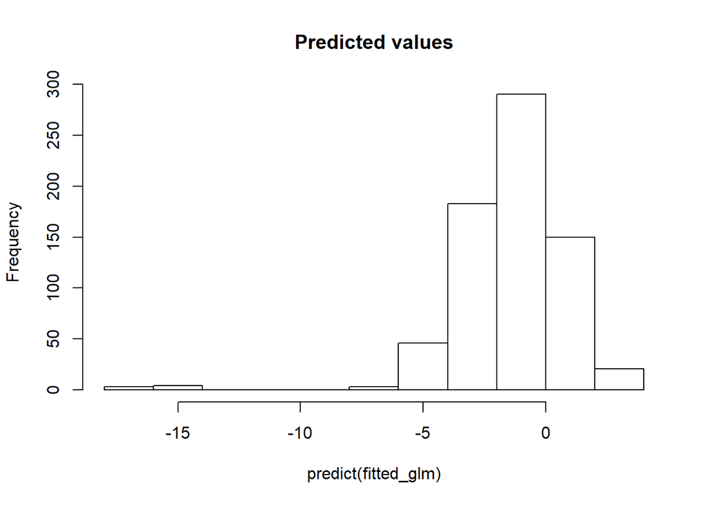

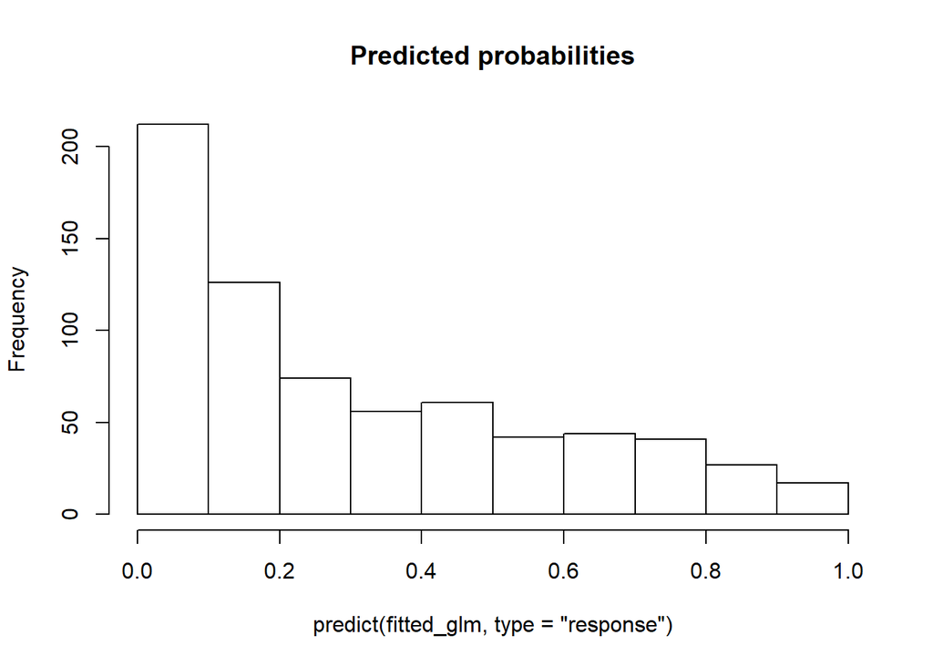

```
##
## FALSE  TRUE
##   301   399
```

```
##      Predicted
## Truth   0   1
##     0 280 206
##     1  21 193
```

```
##
## Training Misclassification Rate:  0.3242857
```

```
##      Predicted
## Truth   0   1
##     0 122  92
##     1  16  70
```

```
##
##  Testing Misclassification Rate:  0.36
```

## Classification Tree

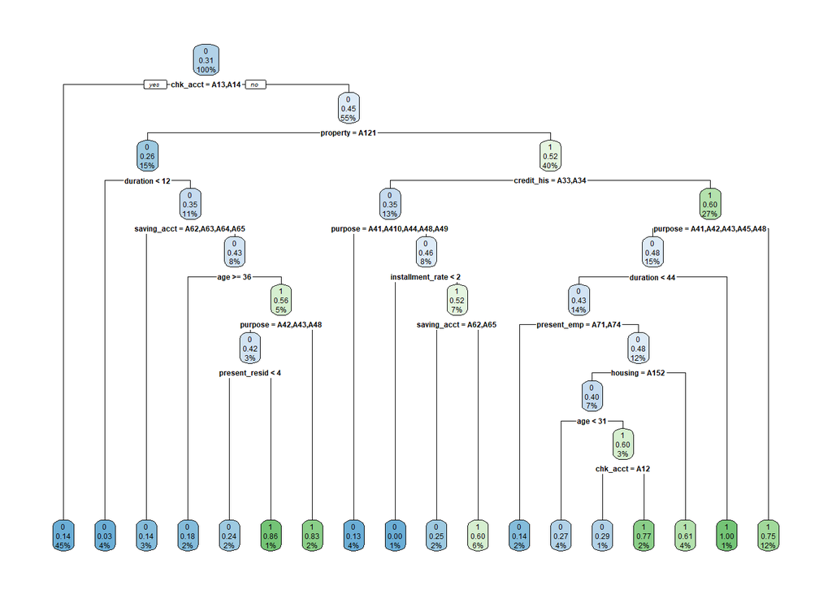

```
##
## Training Misclassification Rate:  0.4842857
```

```
##
##  Testing Misclassification Rate:  0.5216667
```

## GAMs

```
##
## Family: binomial
## Link function: logit
##
## Formula:
## response ~ chk_acct + s(duration) + credit_his + purpose + s(amount) +
##     saving_acct + present_emp + installment_rate + sex + other_debtor +
##     present_resid + property + s(age) + other_install + housing +
##     n_credits + job + n_people + telephone + foreign
##
## Parametric coefficients:
##                     Estimate Std. Error z value Pr(>|z|)
## (Intercept)        1.008e+00  1.323e+00   0.762  0.44616
## chk_acctA12       -2.536e-01  2.713e-01  -0.935  0.34993
## chk_acctA13       -9.816e-01  4.698e-01  -2.089  0.03669 *
## chk_acctA14       -1.738e+00  2.836e-01  -6.130 8.81e-10 ***
## credit_hisA31     -2.023e-02  7.332e-01  -0.028  0.97799
## credit_hisA32     -8.504e-01  6.048e-01  -1.406  0.15968
## credit_hisA33     -1.242e+00  6.415e-01  -1.936  0.05285 .
## credit_hisA34     -1.959e+00  6.029e-01  -3.249  0.00116 **
## purposeA41        -1.455e+00  4.596e-01  -3.166  0.00154 **
## purposeA410       -1.565e+00  1.147e+00  -1.365  0.17232
## purposeA42        -7.521e-01  3.285e-01  -2.290  0.02204 *
## purposeA43        -1.239e+00  3.165e-01  -3.914 9.06e-05 ***
## purposeA44        -7.570e-01  1.327e+00  -0.571  0.56828
## purposeA45        -1.024e+00  6.765e-01  -1.514  0.12997
## purposeA46        -3.233e-02  4.602e-01  -0.070  0.94399
## purposeA48        -3.891e+01  2.536e+07   0.000  1.00000
## purposeA49        -7.384e-01  4.105e-01  -1.799  0.07205 .
## saving_acctA62    -4.871e-01  3.606e-01  -1.351  0.17682
## saving_acctA63    -4.411e-01  5.049e-01  -0.874  0.38233
## saving_acctA64    -1.803e+00  6.751e-01  -2.670  0.00758 **
## saving_acctA65    -1.013e+00  3.252e-01  -3.117  0.00183 **
## present_empA72     1.244e-01  5.322e-01   0.234  0.81516
## present_empA73    -1.310e-02  5.160e-01  -0.025  0.97974
## present_empA74    -7.732e-01  5.672e-01  -1.363  0.17278
## present_empA75    -1.242e-01  5.150e-01  -0.241  0.80938
## installment_rate   2.364e-01  1.136e-01   2.081  0.03739 *
## sexA92            -4.915e-01  4.886e-01  -1.006  0.31444
## sexA93            -9.642e-01  4.697e-01  -2.053  0.04008 *
```

[output cut: 16 more lines]

```
## telephoneA192     -3.749e-01  2.519e-01  -1.489  0.13660
## foreignA202       -1.339e+00  6.932e-01  -1.932  0.05334 .
## ---
## Signif. codes:  0 '***' 0.001 '**' 0.01 '*' 0.05 '.' 0.1 ' ' 1
##
## Approximate significance of smooth terms:
##               edf Ref.df Chi.sq p-value
## s(duration) 1.861  2.354  16.82 0.00043 ***
## s(amount)   3.085  3.880  11.43 0.01955 *
## s(age)      1.000  1.000   0.82 0.36530
## ---
## Signif. codes:  0 '***' 0.001 '**' 0.01 '*' 0.05 '.' 0.1 ' ' 1
##
## R-sq.(adj) =  0.304   Deviance explained = 31.5%
## UBRE = -0.0077168  Scale est. = 1         n = 700
```

```
##
## Family: binomial
## Link function: logit
##
## Formula:
## response ~ s(duration) + s(amount) + s(age) + chk_acct + credit_his +
##     purpose + saving_acct + present_emp + installment_rate +
##     sex + other_debtor + present_resid + property + other_install +
##     housing + n_credits + job + n_people + telephone + foreign
##
## Parametric coefficients:
##                     Estimate Std. Error z value Pr(>|z|)
## (Intercept)        1.008e+00  1.323e+00   0.762  0.44616
## chk_acctA12       -2.536e-01  2.713e-01  -0.935  0.34993
## chk_acctA13       -9.816e-01  4.698e-01  -2.089  0.03669 *
## chk_acctA14       -1.738e+00  2.836e-01  -6.130 8.81e-10 ***
## credit_hisA31     -2.023e-02  7.332e-01  -0.028  0.97799
## credit_hisA32     -8.504e-01  6.048e-01  -1.406  0.15968
## credit_hisA33     -1.242e+00  6.415e-01  -1.936  0.05285 .
## credit_hisA34     -1.959e+00  6.029e-01  -3.249  0.00116 **
## purposeA41        -1.455e+00  4.596e-01  -3.166  0.00154 **
## purposeA410       -1.565e+00  1.147e+00  -1.365  0.17232
## purposeA42        -7.521e-01  3.285e-01  -2.290  0.02204 *
## purposeA43        -1.239e+00  3.165e-01  -3.914 9.06e-05 ***
## purposeA44        -7.570e-01  1.327e+00  -0.571  0.56828
## purposeA45        -1.024e+00  6.765e-01  -1.514  0.12997
## purposeA46        -3.233e-02  4.602e-01  -0.070  0.94399
## purposeA48        -3.891e+01  2.536e+07   0.000  1.00000
## purposeA49        -7.384e-01  4.105e-01  -1.799  0.07205 .
## saving_acctA62    -4.871e-01  3.606e-01  -1.351  0.17682
## saving_acctA63    -4.411e-01  5.049e-01  -0.874  0.38233
## saving_acctA64    -1.803e+00  6.751e-01  -2.670  0.00758 **
## saving_acctA65    -1.013e+00  3.252e-01  -3.117  0.00183 **
## present_empA72     1.244e-01  5.322e-01   0.234  0.81516
## present_empA73    -1.310e-02  5.160e-01  -0.025  0.97974
## present_empA74    -7.732e-01  5.672e-01  -1.363  0.17278
## present_empA75    -1.242e-01  5.150e-01  -0.241  0.80938
## installment_rate   2.364e-01  1.136e-01   2.081  0.03739 *
## sexA92            -4.915e-01  4.886e-01  -1.006  0.31444
## sexA93            -9.642e-01  4.697e-01  -2.053  0.04008 *
```

[output cut: 16 more lines]

```
## telephoneA192     -3.749e-01  2.519e-01  -1.489  0.13660
## foreignA202       -1.339e+00  6.932e-01  -1.932  0.05334 .
## ---
## Signif. codes:  0 '***' 0.001 '**' 0.01 '*' 0.05 '.' 0.1 ' ' 1
##
## Approximate significance of smooth terms:
##               edf Ref.df Chi.sq p-value
## s(duration) 1.861  2.354  16.82 0.00043 ***
## s(amount)   3.085  3.880  11.43 0.01955 *
## s(age)      1.000  1.000   0.82 0.36530
## ---
## Signif. codes:  0 '***' 0.001 '**' 0.01 '*' 0.05 '.' 0.1 ' ' 1
##
## R-sq.(adj) =  0.304   Deviance explained = 31.5%
## UBRE = -0.0077168  Scale est. = 1         n = 700
```

```
## Training MCR:  0.201
```

```
##
## Test MCR:  0.24
```

## Neural Networks

```
##         Predicted
## Observed   0
##        0 214
##        1  86
```

```
## Test Misclassification Rate:  0.2866667
```

```
##
## Test credit cost:  1.433333
```